# vcfFilter

Christian Parobek

November 15, 2014

#### Quality Measure Score Distributions (and allele frequency):

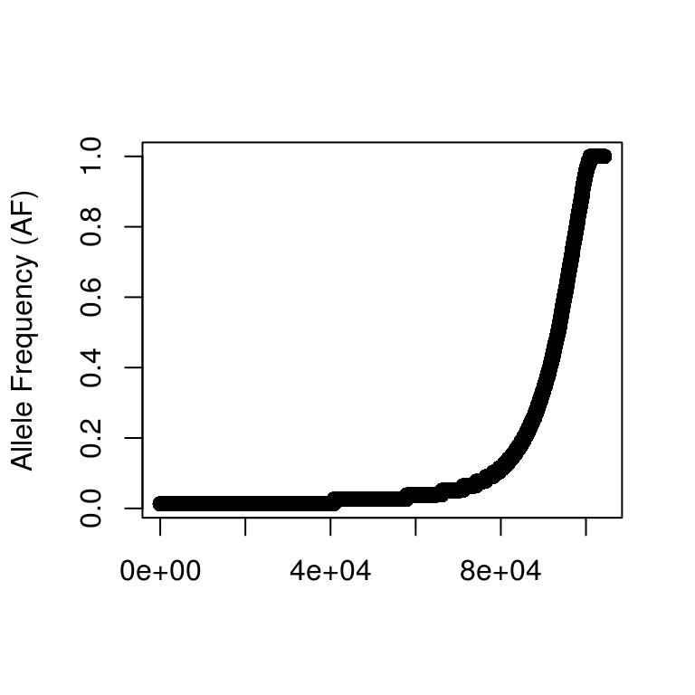

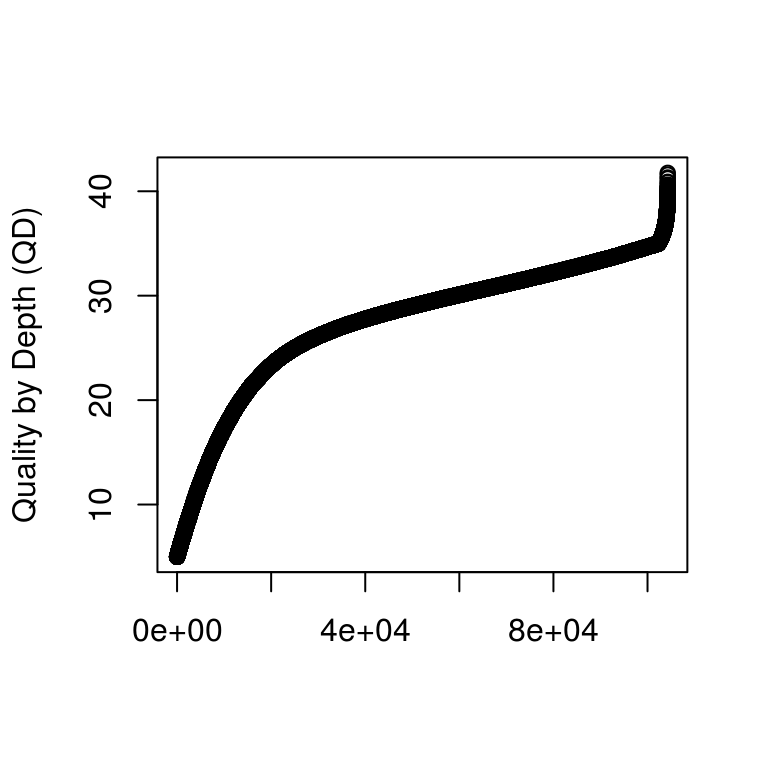

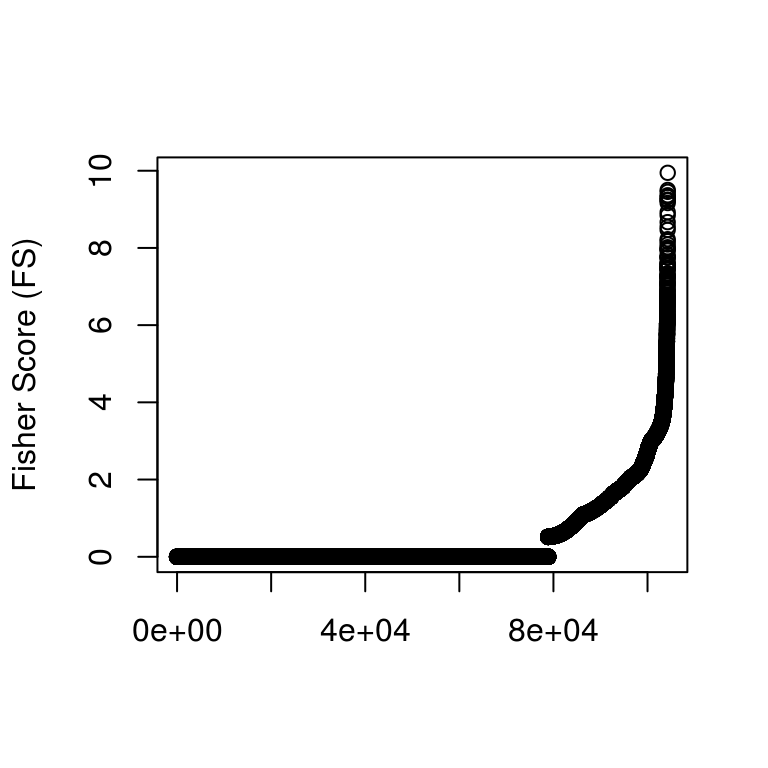

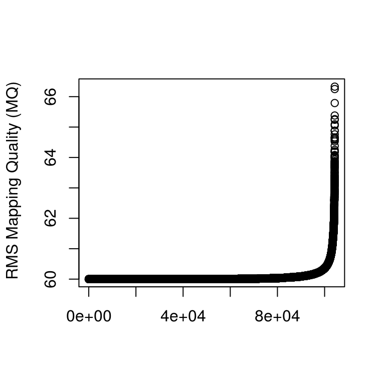

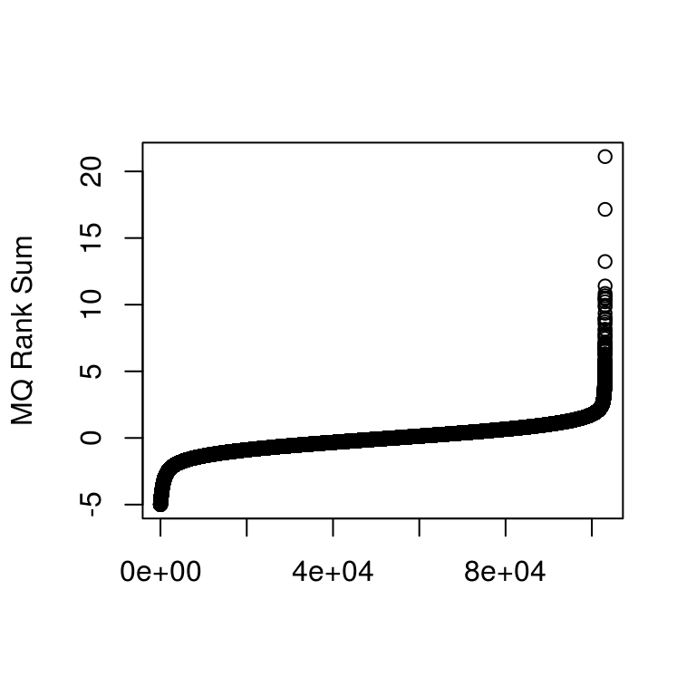

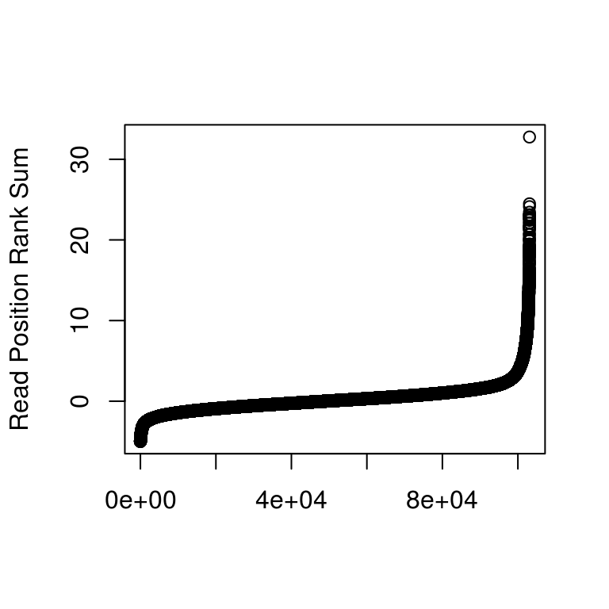

*QD - This is the variant confidence (from the `QUAL` field) divided by the unfiltered depth of non-reference samples. –GATK Documentation*

*FS - Phred-scaled p-value using Fisher’s Exact Test to detect strand bias (the variation being seen on only the forward or only the reverse strand) in the reads. More bias is indicative of false positive calls. –GATK Documentation*

*MQ - Root mean square mapping quality provides an estimation of the overall mapping quality of reads supporting a variant call, averaged over all samples in a cohort. The root mean square is equivalent to the mean of the mapping qualities plus the standard deviation of the mapping qualities. –GATK Documentation*

*Rank-Sum Mapping Quality - This is the u-based z-approximation from the Mann-Whitney Rank Sum Test for mapping qualities (reads with ref bases vs. those with the alternate allele). Note that the mapping quality rank sum test can not be calculated for sites without a mixture of reads showing both the reference and alternate alleles, i.e. this will only be applied to heterozygous calls. –GATK DOcumentation*

*This is the u-based z-approximation from the Mann-Whitney Rank Sum Test for the distance from the end of the read for reads with the alternate allele. If the alternate allele is only seen near the ends of reads, this is indicative of error. Note that the read position rank sum test can not be calculated for sites without a mixture of reads showing both the reference and alternate alleles, i.e. this will only be applied to heterozygous calls. –GATK Documentation*

#### Now let’s look at read depth over within-exon and outside-exon SNPs:

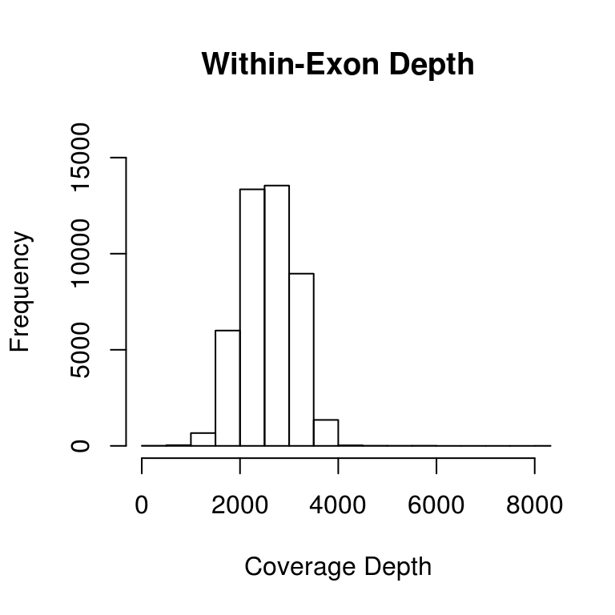

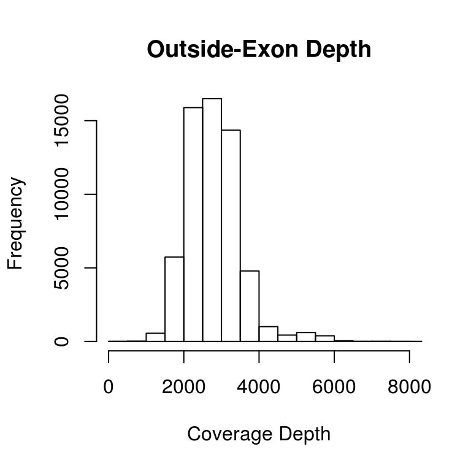

Number SNPs outside exons: 60364  
Outside-exon mean coverage: 2797.946  
Outside-exon median coverage: 2725  
Outside-exon maximum coverage: 8467  
Outside-exon minimum coverage: 7

**Conclusions:** We will be able to use both within-exon and outside-exon SNPs. We will also have to filter by coverage. This step will not remove many SNP entries, but it seems necessary because of the few really low outside-exon SNPs.